# Simulating Spatial Cell-Cell Interactions

9 May 2024

# Contents

# 1 Simulating Spatial Cell-Cell Interactions

scMultiSim can simulate spatial cell-cell interactions. To do so, we need to provide the `cci` option as a list. The following code will print more instructions on how to use the `cci` option.

```r
library(scMultiSim)

scmultisim_help("cci")
```

```
##
## To enable simulating cell-cell interaction, the value should be a list including
## the following names:
##
## - params: (data.frame)
##     The spatial effect between neighbor cells.
##     It should be a data frame similar to the GRN parameter.
## - step.size: (number, optional)
##     If using continuous population, use this step size to further divide the
##     cell types on the tree. For example, if the tree only has one branch 1 -> 2
##     and the branch length is 1 while the step size is 0.34, there will be totally
##     three cell types: 1_2_1, 1_2_2, 1_2_3.
## - cell.type.interaction: ("random" or a matrix)
##     The interaction level between different cell types.
##     They act as factors multiplied to the ligand effect.
##     Supply the string "random" to let scMultiSim generate these factors randomly.
##     Otherwise, use cci_cell_type_params() to generate the template data structure.
##     See the help of this method for more info.
## - max.neighbors: (integer from 1 to 4, optional)
##     Constraint the maxinum number of neighbors with CCI for each cell.
##     The neighbors with CCI will be randomly sampled.
##
```

Now, we prepare a ligand-receptor interaction database. This is pretty similar to the GRN network: it is a data frame with three columns, specifying `target`, `regulator`, and `effect`, respectively. The target and regulator columns should contain the IDs of the target and regulator genes. In the following example, we have two ligand-receptor pairs interacting between two neighboring cells.

```r
lig_params <- data.frame(
  target    = c(101, 102),
  regulator = c(103, 104),
  effect    = c(5.2, 5.9)
)
```

We can now simulate the spatial cell-cell interactions. In scMultiSim, the CCI network is cell-type based, which means that between each cell type pair, we can have a different CCI network sampled from the database defined above. Here, we set the `step.size` to 0.5, so the differentiation tree is divided into segments of length 0.5, each segment is treated as a cell type in CCI. We set `cell.type.interaction` to `random`, so the CCI network between each cell type pair is randomly sampled from the database.

```r
data(GRN_params_100)

options_ <- list(
  rand.seed = 0,
  GRN = GRN_params_100,
  num.genes = 200,
  num.cells = 300,
  num.cifs = 50,
  tree = Phyla3(),
  intrinsic.noise = 0.5,
  cci = list(
    params = lig_params,
    max.neighbors = 4,
    cell.type.interaction = "random",
    step.size = 0.5
  )
)

results <- sim_true_counts(options_)
```

```
## CCI simulation is enabled.
## Get CIF...100..200..300..Done
## Get params...Done
## Simulating...50..100..150..200..250..300..
## Time spent: 5.26 mins
```

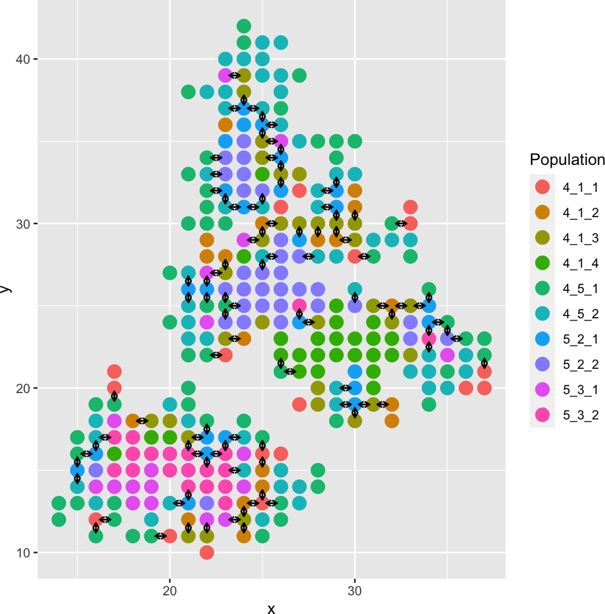

```r
plot_cell_loc(results)
```

The cell locations are available in `results$cci_locs`.

```r
head(results$cci_locs)
```

```
##        x  y
## cell1 26 26
## cell2 24 33
## cell3 30 22
## cell4 20 16
## cell5 24 27
## cell6 27 26
```

## 1.1 Speeding up the Simulation

Simulating spatial cell-cell interactions can be computationally expensive. Setting these two options can speed up the simulation:

```
options_ <- list(
    # ...
    speed.up = T,
    cci = list(
        # ...
        start.layer = ncells
    )
)
```

First of all, it is recommended to set the experimental `speed.up = T` option. This option will become default in later versions of scMultiSim.

Next, it is possible to set the CCI option `start.layer = n_cells`, where `n_cells` is the number of cells. scMultiSim simulates a spatial dataset by following `n_cells` steps, adding one more cell to the spatial grid in each step. Only the final step is outputted as the result. The CCI option `start.layer` can be used to start simulation from a specific time step. When set to `n_cells`, the simulation will skip all previous steps by adding all cells at once. By default, `start.layer` will be set to `n_cells` when number of cells is greater than 800.

# 2 Spatial layouts

scMultiSim provides powerful customization options for spatial cell layouts.

## 2.1 Built-in layouts

scMultiSim ships with several built-in spatial layouts. The `enhanced` layout is the default layout, where cells are added to the grid one by one. When adding a new cell, it has a higher probability of being placed near the existing cells of the same cell type.

```r
# helper function to add `layout` to options, to make the code more readable
spatial_options <- function (...) {
  cci_opt <- list(
    params = lig_params,
    max.neighbors = 4,
    start.layer = 300,
    grid.size = 28,
    cell.type.interaction = "random"
  )
  list(
    rand.seed = 0,
    GRN = GRN_params_100,
    num.genes = 200,
    num.cells = 300,
    num.cifs = 50,
    tree = Phyla3(),
    cci = c(cci_opt, list(...))
  )
}


results <- sim_true_counts(spatial_options(
  layout = "enhanced"
))
```

```
## CCI simulation is enabled.
```

```
## Spatial: only the last layer will be simulated.
```

```
## Get CIF...100..200..300..Done
## Get params...Done
## Simulating...300..
## Time spent: 0.42 mins
```

[figure not shown]

```r
plot_cell_loc(results, show.arrows = FALSE)
```

An option `same.type.prob` decides the probability of a new cell being placed near the existing cells of the same cell type. By default, it is 0.8; and if we use a lower value, the new cell will be placed more randomly.

```r
results <- sim_true_counts(spatial_options(
  layout = "enhanced",
  same.type.prob = 0.1
))
```

```
## CCI simulation is enabled.
```

```
## Spatial: only the last layer will be simulated.
```

```
## Get CIF...100..200..300..Done
## Get params...Done
## Simulating...300..
## Time spent: 0.41 mins
```

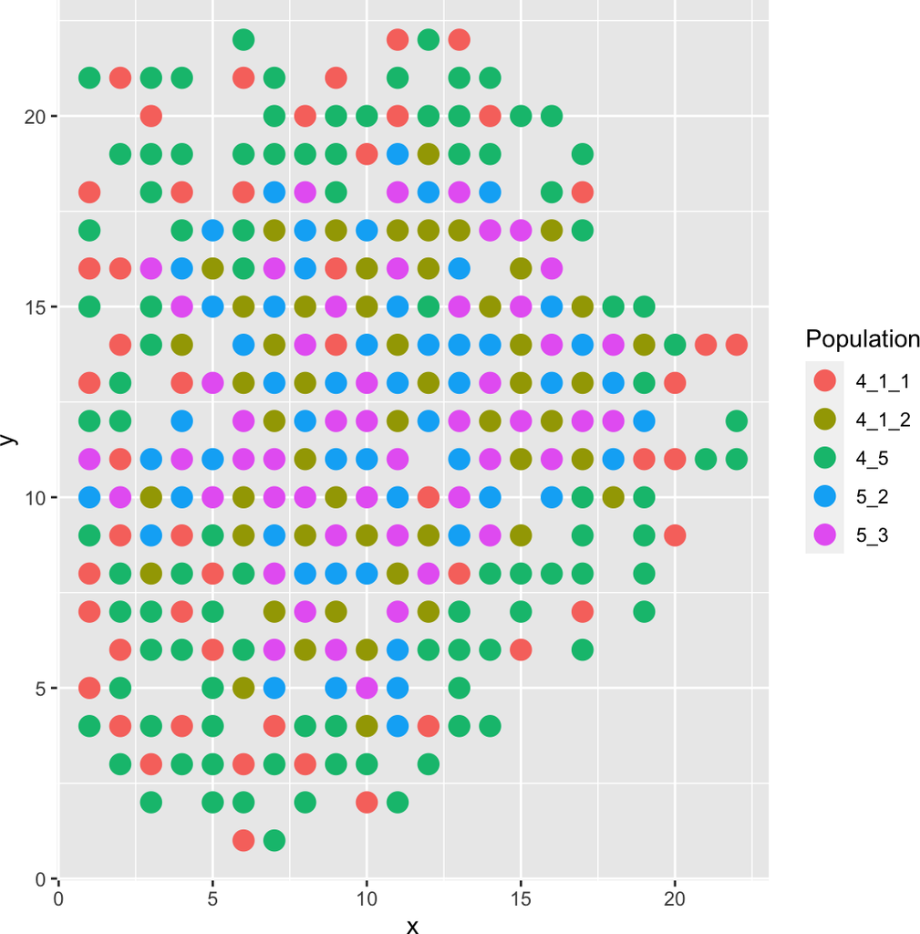

```r
plot_cell_loc(results, show.arrows = FALSE)
```

The `layers` layout arranges cells in layers.

```r
results <- sim_true_counts(spatial_options(
  layout = "layers"
))
```

```
## CCI simulation is enabled.
```

```
## Spatial: only the last layer will be simulated.
```

```
## Get CIF...100..200..300..Done
## Get params...Done
## Simulating...300..
## Time spent: 0.40 mins
```

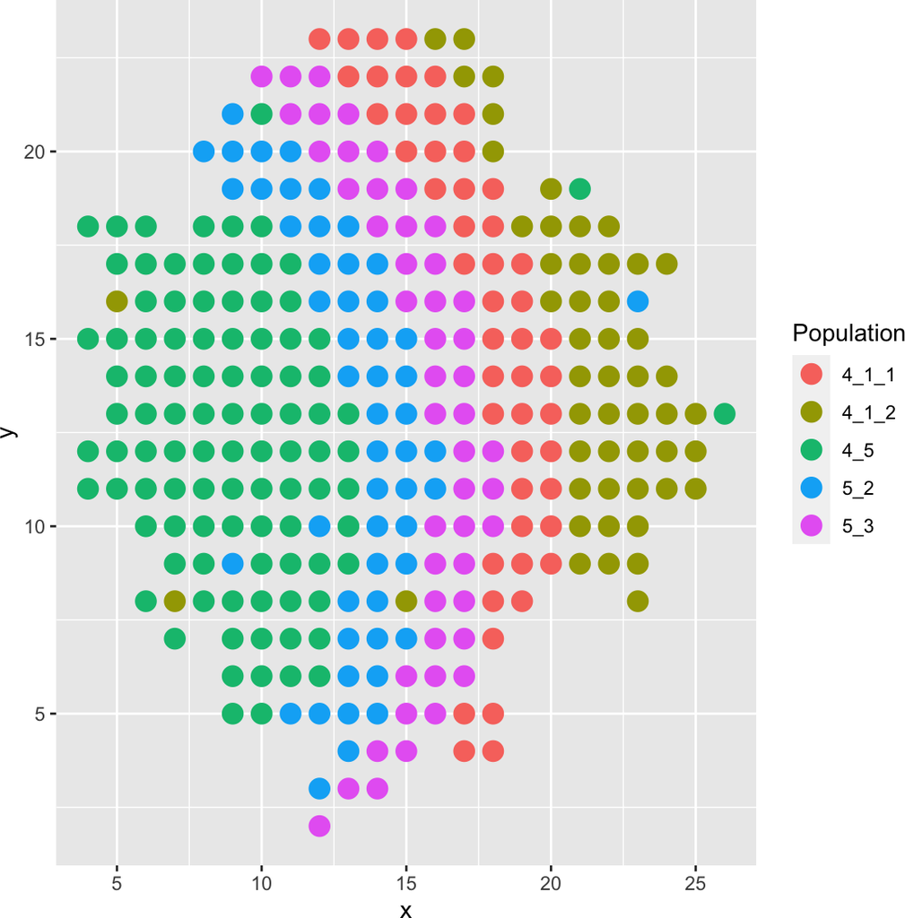

```r
plot_cell_loc(results, show.arrows = FALSE)
```

The `islands` layout will put some cell types in the center like islands, and others around them. You may specify which cell type should be islands in the format `islands:1,2,3`. The number here can be looked up in `results$cci_cell_types`.

```r
results$cci_cell_types
```

```
##   4_5   5_2   5_3 4_1_1 4_1_2
##     1     2     3     4     5
```

```r
results <- sim_true_counts(spatial_options(
  # cell type 4_1_2 should be the island
  layout = "islands:5"
))
```

```
## CCI simulation is enabled.
```

```
## Spatial: only the last layer will be simulated.
```

```
## Get CIF...100..200..300..Done
## Get params...Done
## Simulating...300..
## Time spent: 0.40 mins
```

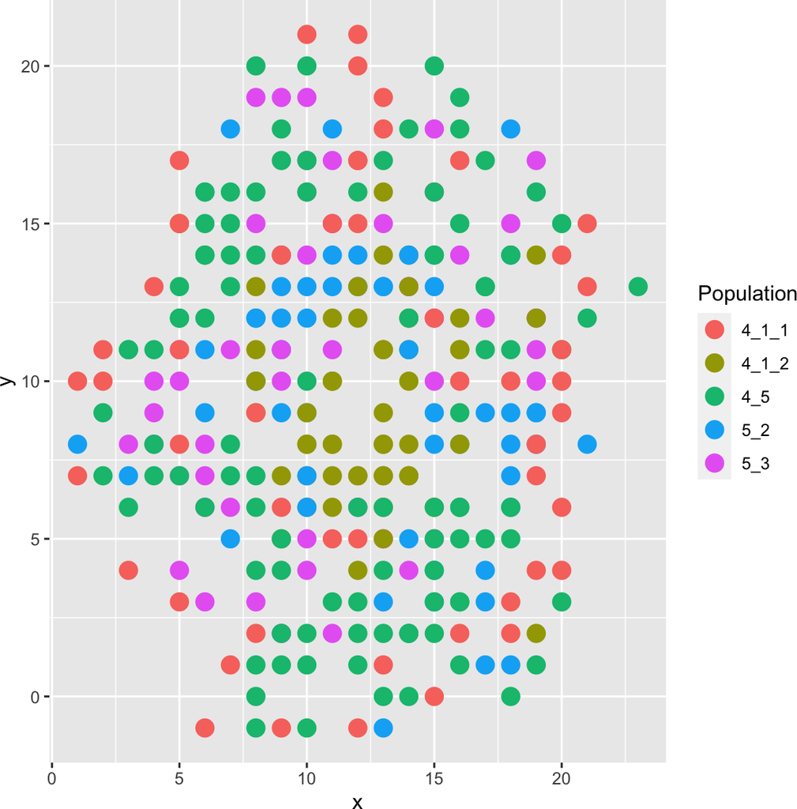

```r
plot_cell_loc(results, show.arrows = FALSE)
```

## 2.2 Custom layouts

It is also possible to layout the cells programmatically. The `layout` option can be a function that takes the cell type information and returns the spatial locations of the cells:

```
# grid_size is a number
# cell_types is an integer vector, representing the cell types
function(grids_size, cell_types) {
  # return a matrix with two columns, representing the x and y coordinates of the cells
  return matrix(nrow = 2, ncol = ncells)
}
```

For example, the following layout function will place the cells sequentially in the grid, starting from the bottom-left corner.

```r
results <- sim_true_counts(spatial_options(
  layout = function (grid_size, cell_types) {
    ncells <- length(cell_types)
    new_locs <- matrix(nrow = ncells, ncol = 2)
    # for each cell...
    for (i in 1:ncells) {
      # ...place it in the grid
      new_locs[i,] <- c(i %% grid_size, i %/% grid_size)
    }
    return(new_locs)
  }
))
```

```
## CCI simulation is enabled.
```

```
## Spatial: only the last layer will be simulated.
```

```
## Get CIF...100..200..300..Done
## Get params...Done
## Simulating...300..
## Time spent: 0.40 mins
```

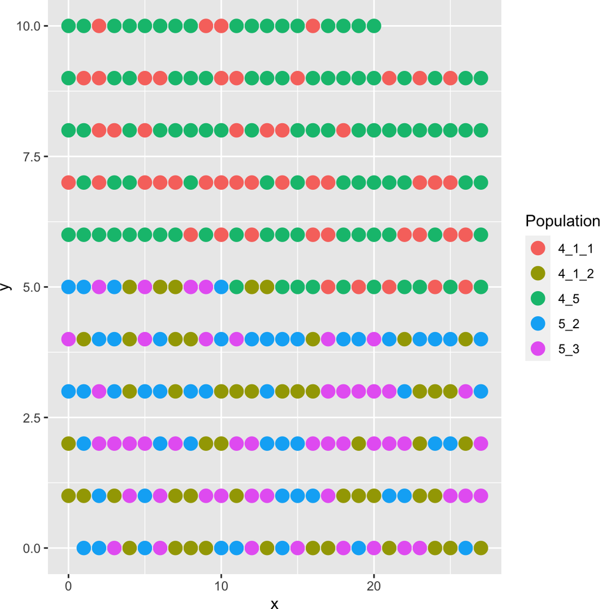

```r
plot_cell_loc(results, show.arrows = FALSE)
```

## 2.3 Spatial domains

Next, we demonstrate how to use custom layout function to create spatial domains. We want to have three spatial domains in a layered layout, and we have four cell types. Each cell type has a different probability of being in each domain.

The following layout function will do this job: First of all, it generates a set of locations that form a circular shape. Next, it assigns cells to these locations; the leftmost cell is selected as the origin. Then, we can create a layered layout by sorting the locations based on their euclidian distance to the origin. The three domains are determined by the distance to the origin. We have a matrix `ct_matrix` that specifies the probability of each cell type being in each domain. Finally, we sample the cells based on the probabilities and assign them to the domains.

```r
layout_fn <- function(grid_size, final_types) {
  ncells <- length(final_types)
  grid_center <- c(round(grid_size / 2), round(grid_size / 2))
  all_locs <- gen_clutter(ncells, grid_size, grid_center)
  # center is bottom-left
  left_ones <- which(all_locs[,1] == min(all_locs[,1]))
  new_center <<- all_locs[left_ones[which.min(all_locs[left_ones, 2])],]
  dist_to_center <- sqrt(colSums((t(all_locs) - new_center)^2))
  new_locs <- all_locs[order(dist_to_center),]
  # prob of a cell type being in a zone (cell_type x zone)
  ct_matrix <- matrix(c(
    0.9, 0.1, 0.0,
    0.1, 0.8, 0.1,
    0.1, 0.7, 0.2,
    0.0, 0.1, 0.9
  ), nrow = 4, byrow = TRUE)
  # number of cells per type
  ct_pop <- c(160, 80, 100, 140)
  pop_mtx <- round(ct_matrix * ct_pop)
  if (sum(pop_mtx) != ncells) {
    diffrence <- ncells - sum(pop_mtx)
    pop_mtx[1, 1] <- pop_mtx[1, 1] + diffrence
  }
  # number of cells per zone
  zone_pop <- colSums(pop_mtx)
  # assign cells to zones
  cs <- cumsum(zone_pop)
  # sample cells
  cell_idx <- lapply(1:3, function(izone) {
    sample(rep(1:4, pop_mtx[,izone]), zone_pop[izone])
  }) %>% unlist()
  locs <<- new_locs[order(cell_idx),]
  zone_gt <<- rep(1:3, zone_pop)[order(cell_idx)]
  return(locs)
}
```

Inspecting the result, we can see the three spatial domains, where the middle one contains a mix of two cell types.

```r
results <- sim_true_counts(list2(
  num.cells = 500,
  num.genes = 300,
  num.cifs = 40,
  GRN = NA,
  speed.up = T,
  cif.sigma = 0.8,
  tree = ape::read.tree(text = "(A:1,B:1,C:1,D:1);"),
  diff.cif.fraction = 0.8,
  discrete.cif = T,
  discrete.pop.size = as.integer(c(120,150,100,130)),
  cci = list(
    params = lig_params,
    max.neighbors = 4,
    start.layer = 500,
    cell.type.interaction = "random",
    layout = layout_fn,
    step.size = 1
  )
))
```

```
## Experimental speed optimization enabled.
```

```
## CCI simulation is enabled.
```

```
## Spatial: only the last layer will be simulated.
```

```
## Get CIF...Get params...Done
## Simulating...500..
## Time spent: 0.26 mins
```

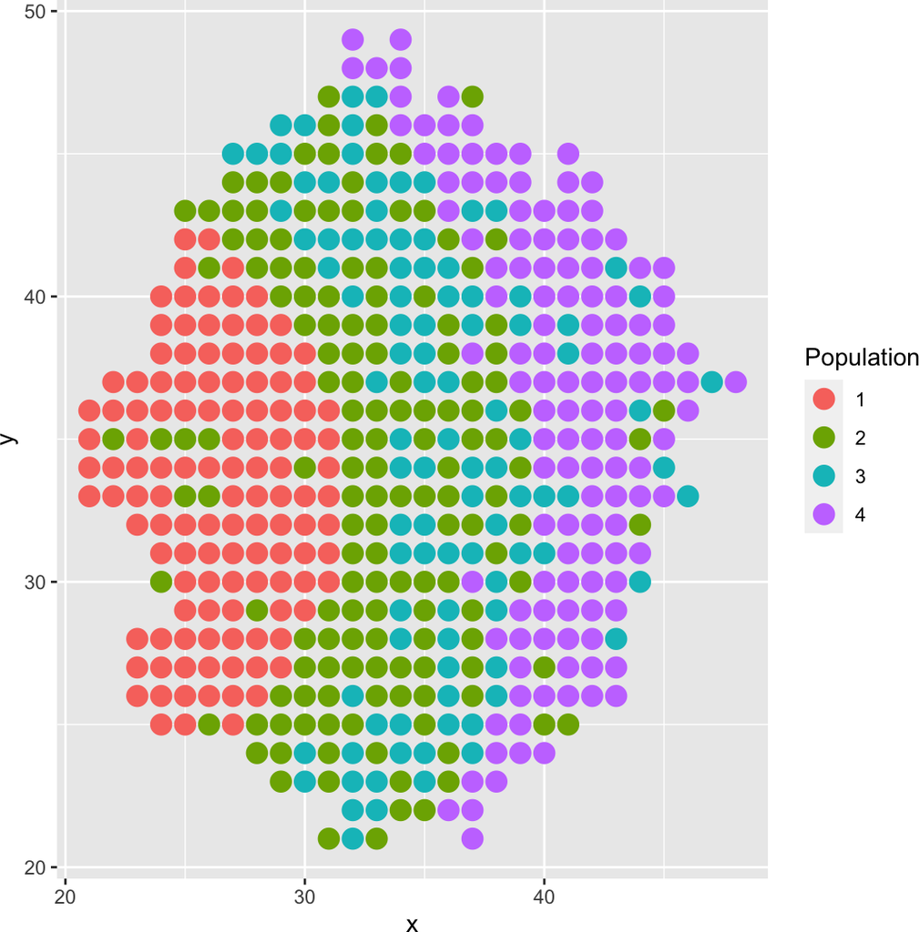

```r
plot_cell_loc(results, show.arrows = FALSE)
```

## 2.4 Spatially variable genes

The `ext.cif.giv` option allows us to append custom CIF and GIV entries for each cell and gene. We can use this option to simulate spatially variable genes. This option should be a function that takes the kinetic parameter index and returns a list of extra CIF and GIV matrices.

```r
scmultisim_help("ext.cif.giv")
```

```
## ext.cif.giv  (default: NA)
##  Add customized CIF and GIV. The function takes one argument, the kinetic
##   parameter index (1=kon, 2=koff, 3=s). It should return a list of two el
##  ements: the extra CIF matrix (n_extra_cif x n_cells) and the GIV matrix
##  (n_genes x n_extra_cif). Return NULL for no extra CIF and GIV.
##  should be a function
```

Using the previous layout function, we can add extra CIF with value based on the distance to the origin.

```r
ext_cif <- function(i) {
  # We manually set genes 290-300 to be spatially variable
  spatial_genes <- 290:300
  dist_to_center <- colSums((t(locs) - new_center)^2)
  dist_to_center <- dist_to_center / max(dist_to_center)
  # 3 is the s parameter
  if (i == 3) {
    # n_extra_cif x n_cells
    ex_cif <- cbind(
      # the two CIFs have large values when distance to the center is near 0.5
      rnorm(500, 0.5 * dnorm(abs(dist_to_center - 0.5), 0, 0.04), 0.02),
      rnorm(500, 0.5 * dnorm(abs(dist_to_center - 0.5), 0, 0.04), 0.02)
    )
    # n_genes x n_extra_cif
    ex_giv <- matrix(0, nrow = 300, ncol = 2)
    for (i in spatial_genes) {
      # odd genes affected by the first two CIF, even genes affected by the last two CIF
      ex_giv[i, ] <- rnorm(2, 1, 0.5)
    }
    list(ex_cif, ex_giv * 2)
  } else {
    NULL
  }
}
```

```r
results <- sim_true_counts(list2(
  num.cells = 500,
  num.genes = 300,
  num.cifs = 40,
  GRN = NA,
  speed.up = T,
  cif.sigma = 0.8,
  tree = ape::read.tree(text = "(A:1,B:1,C:1,D:1);"),
  diff.cif.fraction = 0.8,
  ext.cif.giv = ext_cif,
  discrete.cif = T,
  discrete.pop.size = as.integer(c(120,150,100,130)),
  cci = list(
    params = lig_params,
    max.neighbors = 4,
    start.layer = 500,
    cell.type.interaction = "random",
    layout = layout_fn,
    step.size = 1
  )
))
```

```
## Experimental speed optimization enabled.
```

```
## CCI simulation is enabled.
```

```
## Spatial: only the last layer will be simulated.
```

```
## Get CIF...Get params...Done
## Simulating...500..
## Time spent: 0.26 mins
```

Try plotting one of the spatially variable genes. We can see that the gene expression is higher in the specific spatial region.

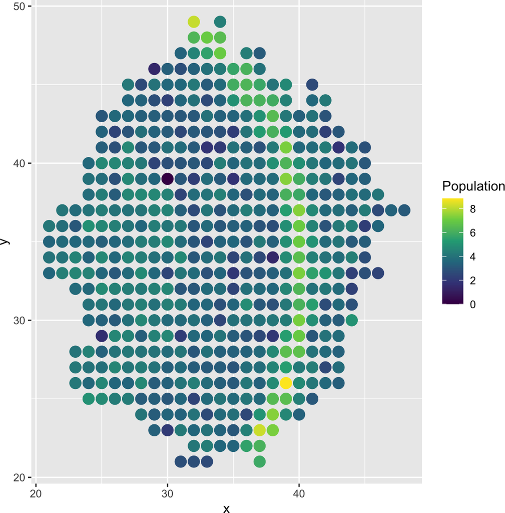

```r
plot_cell_loc(results, show.arrows = FALSE,
              .cell.pop = log(results$counts[299,] + 1)) + scale_colour_viridis_c()
```